# Project 2: Horse Colic

Melodie Irvin, mki77

Colic is a cause for many horse emergencies in veterinary medicine due to the severity of the abdominal obstructions that may occur. Colic itself is not a diagnosis, but rather a symptom of a larger problem that is usually found in the Gastrointestinal tract. This dataset, found on Kaggle, consists of different parameters measuring the health of 209 horses with colic. The main variables I will be focusing on are surgery (yes or no), outcome (lived or died), abdomen, total protein, and packed cell volume. Total Protein is a measure of the total amount of Albumin and Globulin in the blood, and increased levels typically indicate dehydration in the mammal. Packed cell volume is a measure of the amount of red blood cells by volume in blood, and like total protein counts, an increase in levels may indicate dehydration. Dehydration that results in colic is a common problem that can be caused by a change in feed, in addition to a loss of water intake. This combination results in obstructions that occur in the abdomen. The variable for abdomen measures possible indexes of abdominal presentation. Distended large and small intestines typically indicate an obstruction present in the GI tract due to a mechanical impaction which often requires immediate surgery. Less severe abdominal findings, however, may not need surgery and can be fixed with the use of different types of medications.

```r
options(repos="https://cran.rstudio.com" )
library(readxl);library(tidyverse)
horse <- read_excel("C:/Users/Melodie/Desktop/horse.xlsx")
man1<-manova(cbind(total_protein,packed_cell_volume)~outcome, data=horse)
summary(man1)
```

```
##            Df  Pillai approx F num Df den Df   Pr(>F)
## outcome     1 0.23698   31.989      2    206 7.97e-13 ***
## Residuals 207
## ---
## Signif. codes:  0 '***' 0.001 '**' 0.01 '*' 0.05 '.' 0.1 ' ' 1
```

```r
summary.aov(man1)
```

```
##  Response total_protein :
##              Df Sum Sq Mean Sq F value   Pr(>F)
## outcome       1   6949  6949.3  10.076 0.001731 **
## Residuals   207 142766   689.7
## ---
## Signif. codes:  0 '***' 0.001 '**' 0.01 '*' 0.05 '.' 0.1 ' ' 1
##
##  Response packed_cell_volume :
##              Df  Sum Sq Mean Sq F value    Pr(>F)
## outcome       1  4472.8  4472.8  51.754 1.132e-11 ***
## Residuals   207 17889.5    86.4
## ---
## Signif. codes:  0 '***' 0.001 '**' 0.01 '*' 0.05 '.' 0.1 ' ' 1
```

```r
horse%>%group_by(outcome)%>%summarize(mean(total_protein),mean(packed_cell_volume))
```

```
## # A tibble: 2 x 3
##   outcome `mean(total_protein)` `mean(packed_cell_volume)`
##   <chr>                   <dbl>                      <dbl>
## 1 died                     15.6                       52.1
## 2 lived                    27.4                       42.6
```

```r
pairwise.t.test(horse$total_protein,horse$outcome,
                p.adj="none")
```

```
##
##  Pairwise comparisons using t tests with pooled SD
##
## data:  horse$total_protein and horse$outcome
##
##       died
## lived 0.0017
##
## P value adjustment method: none
```

```r
pairwise.t.test(horse$packed_cell_volume,horse$outcome,
                p.adj="none")
```

```
##
##  Pairwise comparisons using t tests with pooled SD
##
## data:  horse$packed_cell_volume and horse$outcome
##
##       died
## lived 1.1e-11
##
## P value adjustment method: none
```

```r
1-.95^5
```

```
## [1] 0.2262191
```

```r
.05/5
```

```
## [1] 0.01
```

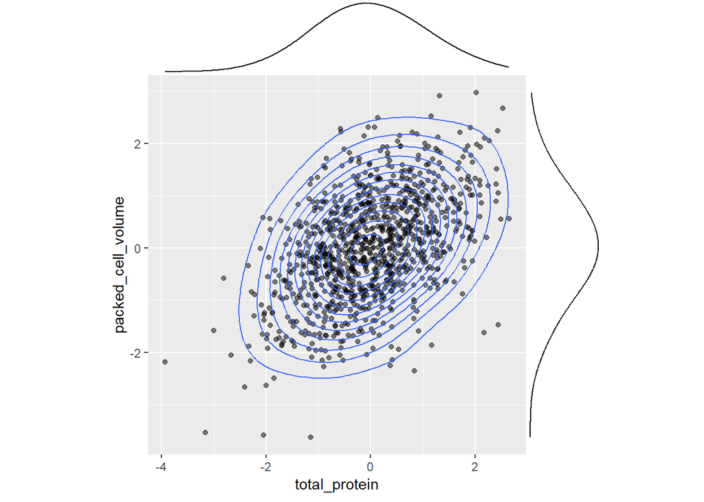

```r
library(mvtnorm); library(ggExtra)
df<-rmvnorm(1000,mean=c(0,0),sigma=matrix(c(1,.5,.5,1),ncol=2,byrow=T))
df<-data.frame(df)%>%rename(total_protein=X1,packed_cell_volume=X2)
p<-ggplot(df, aes(total_protein,packed_cell_volume))+geom_point(alpha=.5)+geom_density_2d(h=2)+coord_fixed()
ggMarginal(p,type="density",xparams = list(bw=.5), yparams=list(bw=.5))
```

```r
cov(df)
```

```
##                    total_protein packed_cell_volume
## total_protein          1.0061264          0.4831434
## packed_cell_volume     0.4831434          0.9944225
```

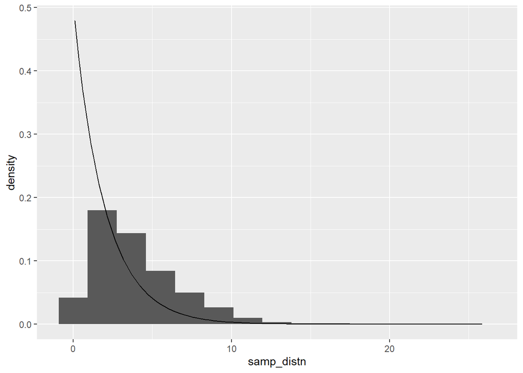

```r
samp_distn<-vector()
for(i in 1:5000){
  horse$pain<-sample(horse$pain)
  obs<-table(horse$pain,horse$surgery)
  exp<-outer(rowSums(obs),colSums(obs),"*")/sum(obs)
  samp_distn[i]<-sum((obs-exp)^2/exp)
}
data.frame(samp_distn)%>%
  ggplot(aes(samp_distn))+geom_histogram(aes(y=..density..),bins = 15)+
  stat_function(fun=dchisq,args=list(df=2),geom="line")
```

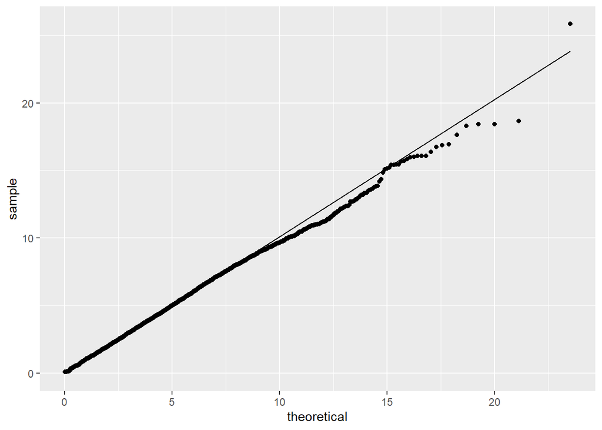

```r
data.frame(samp_distn)%>%
  ggplot(aes(sample=samp_distn)) +
  stat_qq(distribution = qchisq, dparams = list(df=4)) +
  stat_qq_line(distribution = qchisq, dparams = list(df=4))
```

```r
library(ggplot2);library(lmtest);library(sandwich)
horse1<-horse
horse1$TP_c <- horse1$total_protein - mean(horse1$total_protein)
fit<-lm(packed_cell_volume~age+TP_c+abdominal_distention+surgery:TP_c, data=horse1)
summary(fit)
```

```
##
## Call:
## lm(formula = packed_cell_volume ~ age + TP_c + abdominal_distention +
##     surgery:TP_c, data = horse1)
##
## Residuals:
##     Min      1Q  Median      3Q     Max
## -22.038  -6.992  -1.442   4.883  30.997
##
## Coefficients:
##                            Estimate Std. Error t value Pr(>|t|)
## (Intercept)                48.06257    1.32706  36.217  < 2e-16 ***
## ageyoung                   -7.08464    2.70467  -2.619  0.00948 **
## TP_c                       -0.05931    0.03995  -1.485  0.13920
## abdominal_distentionnone   -3.19217    1.81260  -1.761  0.07973 .
## abdominal_distentionsevere  6.09516    2.25733   2.700  0.00752 **
## abdominal_distentionslight -3.52117    1.83149  -1.923  0.05594 .
## TP_c:surgeryyes             0.04881    0.05194   0.940  0.34843
## ---
## Signif. codes:  0 '***' 0.001 '**' 0.01 '*' 0.05 '.' 0.1 ' ' 1
##
## Residual standard error: 9.843 on 202 degrees of freedom
## Multiple R-squared:  0.1248, Adjusted R-squared:  0.09878
## F-statistic:   4.8 on 6 and 202 DF,  p-value: 0.0001337
```

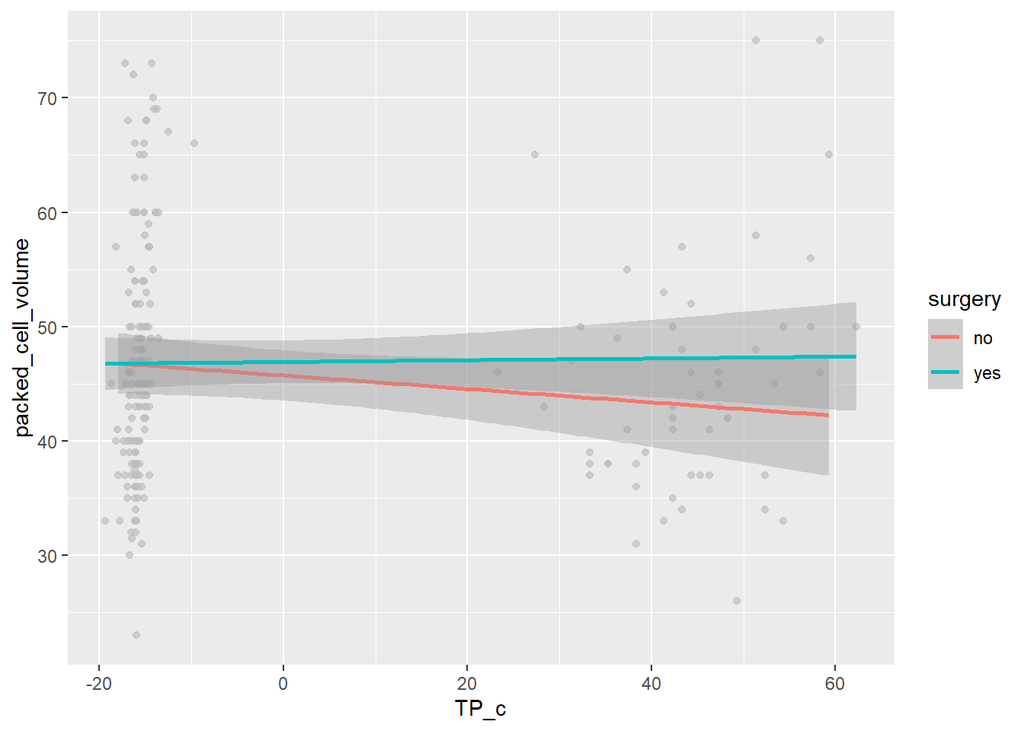

```r
fit %>%
  ggplot() +
  aes(x = TP_c, y = packed_cell_volume, group = surgery, color = surgery) +
  geom_point(color = "grey", alpha = .7) +
  geom_smooth(method = "lm")
```

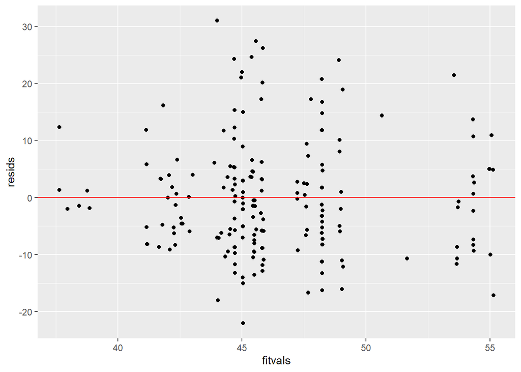

```r
resids<-fit$residuals; fitvals<-fit$fitted.values
ggplot()+geom_point(aes(fitvals,resids))+geom_hline(yintercept=0, col="red")
```

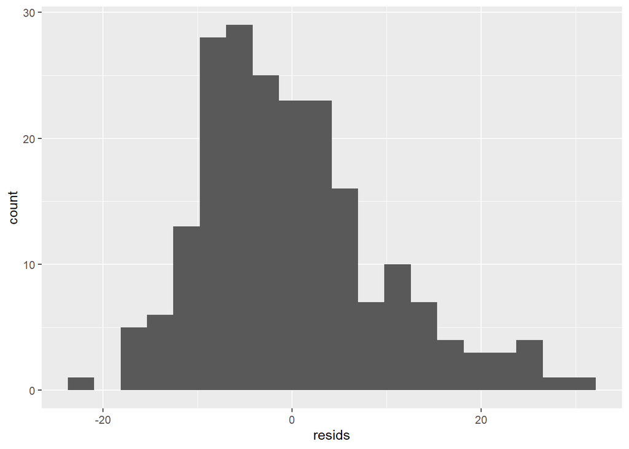

```r
ggplot()+geom_histogram(aes(resids),bins=20)
```

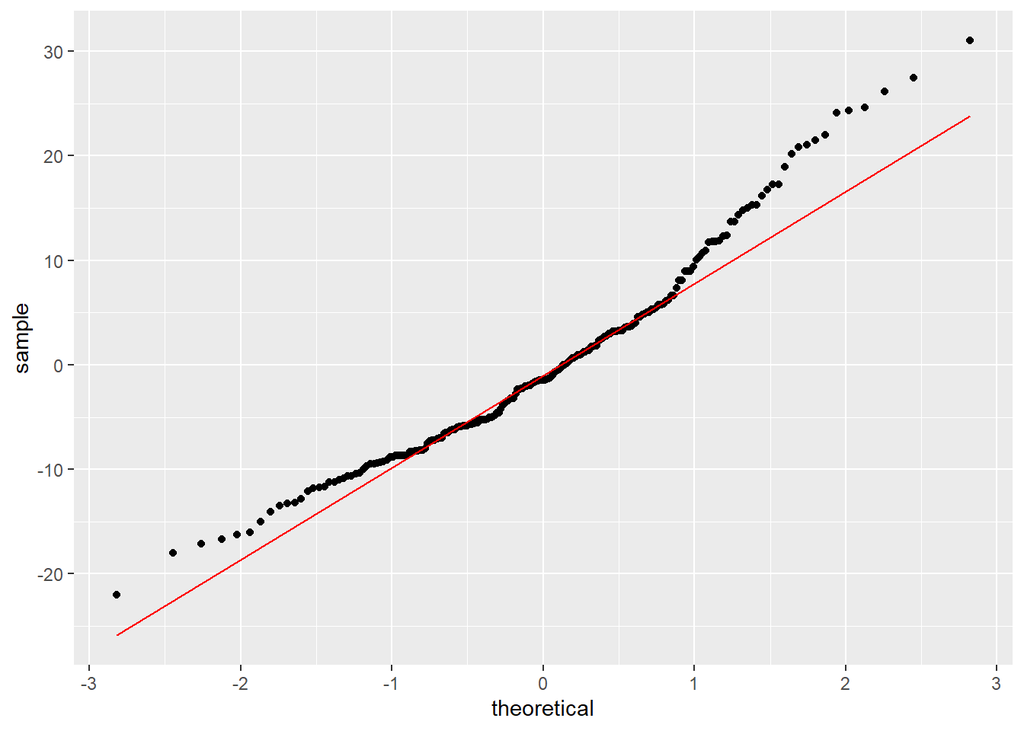

```r
ggplot()+geom_qq(aes(sample=resids))+geom_qq_line(aes(sample=resids), color='red')
```

```r
bptest(fit)
```

```
##
##  studentized Breusch-Pagan test
##
## data:  fit
## BP = 5.9423, df = 6, p-value = 0.4297
```

```r
coeftest(fit, vcov = vcovHC(fit))[,1:2] #Robust SEs. Get normal SEs from fit
```

```
##                               Estimate Std. Error
## (Intercept)                48.06256706 1.33324160
## ageyoung                   -7.08463957 2.00070523
## TP_c                       -0.05931106 0.03612691
## abdominal_distentionnone   -3.19217178 1.81330103
## abdominal_distentionsevere  6.09516031 2.24806217
## abdominal_distentionslight -3.52117451 1.89147462
## TP_c:surgeryyes             0.04881339 0.05190732
```

```r
coeftest(fit)[,1:2] # NOrmal SEs
```

```
##                               Estimate Std. Error
## (Intercept)                48.06256706 1.32705980
## ageyoung                   -7.08463957 2.70467241
## TP_c                       -0.05931106 0.03995003
## abdominal_distentionnone   -3.19217178 1.81259738
## abdominal_distentionsevere  6.09516031 2.25733249
## abdominal_distentionslight -3.52117451 1.83149172
## TP_c:surgeryyes             0.04881339 0.05193841
```

Interpretations of coefficient estimates: (Intercept): Predicted packed cell volume for an adult horse with an average total protein count and no surgery is 48.062 microliters. (TP_c): Controlling for age young, horses with no surgery show a decrease of .059 microliter in packed cell volume for every one unit increase in total protein on average. (Abdominal_distention_none:) Controlling for age, a horse with average total protein has a packed cell volume that is 3.19 microliters lower for horses with no abdominal distention compared to horses with abdominal distention. (Abdominal_distention_severe:) Controlling for age, a horse with average total protein has a packed cell volume that is 6.10 micoliters higher for horses with severe abdominal distention compared to horses without abdominal distention. (Abdominal_distention_slight:) Controlling for age, a horse with average total protein has a packed cell volume that is 3.52 microliters lower for horses with slight abdominal distention compared to horses without abdominal distention. (Age_young:) Controlling for Abdominal distention, a horse with average total protein has a packed cell volume that is 7.08 microliters lower for young horses compared to adult horses.

The null hypothesis for a Breusch-Pagan test states that the data is homoskedastic. Based on a p-value of .42, we fail to reject the null hypothesis concluding that the data homoskedastic. Normality was tested using ggplot to plot residuals, and was found to be an okay indicator of normality.

The assumption for homoskedasticity was confirmed with the Breush-Pagan test confirming equal variances. However, the Normal Standard Errors did not predictably increase when Robust Standard Errors were calculated. It is normal for standard errors to increase when testing for robust standard errors due to the lack of need for meeting assumptions. Overall, the standard errors did not change much, and some did increase with Robust standard errors, but those that decreased may have been becasue heteroskedasticity may make normal standard errors upward biased.

Based on the Adjusted R squared value given from the coeftest, the model explains 9.87% of the variation in the outcome.

```r
fit<-lm(packed_cell_volume~age+TP_c+abdominal_distention+surgery:TP_c, data=horse1)
boot_dat<- sample_frac(horse, replace=T)

samp_distn<-replicate(5000, {
  boot_dat <- sample_frac(horse1, replace=T)
  fit <- lm(packed_cell_volume~age+TP_c+abdominal_distention+surgery:TP_c, data=boot_dat)
  coef(fit)
})

samp_distn %>% t %>% as.data.frame %>% summarize_all(sd)
```

```
##   (Intercept) ageyoung       TP_c abdominal_distentionnone
## 1    1.315618 1.958456 0.03548638                 1.773901
##   abdominal_distentionsevere abdominal_distentionslight TP_c:surgeryyes
## 1                   2.197172                   1.839817      0.05078941
```

```r
fit<-lm(packed_cell_volume~age+TP_c+abdominal_distention+surgery:TP_c, data=horse1)
resids<-fit$residuals
fitted<-fit$fitted.values
resid_resamp<-replicate(5000,{
  new_resids<-sample(resids,replace=TRUE)
  horse1$new_y<-fitted+new_resids
  fit<-lm(new_y~age+TP_c+abdominal_distention+surgery:TP_c, data=horse1)
  coef(fit)
})

resid_resamp%>%t%>%as.data.frame%>%summarize_all(sd)
```

```
##   (Intercept) ageyoung       TP_c abdominal_distentionnone
## 1    1.324234 2.645504 0.03893682                 1.772414
##   abdominal_distentionsevere abdominal_distentionslight TP_c:surgeryyes
## 1                   2.275835                   1.815408      0.05057686
```

```r
log_horse<-horse%>%mutate(y=ifelse(outcome=="died",1,0))%>%drop_na(abdominal_distention)
head(log_horse)
```

```
## # A tibble: 6 x 16
##   surgery age   temp_of_extremi~ peripheral_pulse mucous_membrane
##   <chr>   <chr> <chr>            <chr>            <chr>
## 1 no      adult cool             reduced          NA
## 2 yes     adult NA               NA               pale_cyanotic
## 3 no      adult normal           normal           pale_pink
## 4 yes     young cold             normal           dark_cyanotic
## 5 yes     adult normal           normal           normal_pink
## 6 no      adult cool             absent           pale_pink
## # ... with 11 more variables: capillary_refill_time <chr>, pain <chr>,
## #   peristalsis <chr>, abdominal_distention <chr>, nasogastric_tube <chr>,
## #   rectal_exam_feces <chr>, abdomen <chr>, packed_cell_volume <dbl>,
## #   total_protein <dbl>, outcome <chr>, y <dbl>
```

```r
fit2<-glm(y~surgery+abdominal_distention, family="binomial", data=log_horse)
coeftest(fit2)
```

```
##
## z test of coefficients:
##
##                            Estimate Std. Error z value  Pr(>|z|)
## (Intercept)                 0.45192    0.37345  1.2101 0.2262326
## surgeryyes                  0.11318    0.32993  0.3431 0.7315608
## abdominal_distentionnone   -1.87279    0.42502 -4.4064 1.051e-05 ***
## abdominal_distentionsevere  0.10837    0.47794  0.2267 0.8206252
## abdominal_distentionslight -1.49305    0.41330 -3.6125 0.0003032 ***
## ---
## Signif. codes:  0 '***' 0.001 '**' 0.01 '*' 0.05 '.' 0.1 ' ' 1
```

```r
exp(coef(fit2))
```

```
##                (Intercept)                 surgeryyes
##                  1.5713193                  1.1198354
##   abdominal_distentionnone abdominal_distentionsevere
##                  0.1536938                  1.1144582
## abdominal_distentionslight
##                  0.2246866
```

```r
prob<-predict(fit2, type="response")
pred<-ifelse(prob > .5,1,0)
table(prediction=pred, truth=log_horse$y)%>%addmargins
```

```
##           truth
## prediction   0   1 Sum
##        0    94  29 123
##        1    31  55  86
##        Sum 125  84 209
```

```r
#accuracy
(94+55)/209
```

```
## [1] 0.7129187
```

```r
#Specificity
94/125
```

```
## [1] 0.752
```

```r
#Sensitivity
55/84
```

```
## [1] 0.6547619
```

```r
odds<-function(p)p/(1-p)
p<-seq(0,1,by=.1)
cbind(p, odds=odds(p))%>%round(4)
```

```
##         p   odds
##  [1,] 0.0 0.0000
##  [2,] 0.1 0.1111
##  [3,] 0.2 0.2500
##  [4,] 0.3 0.4286
##  [5,] 0.4 0.6667
##  [6,] 0.5 1.0000
##  [7,] 0.6 1.5000
##  [8,] 0.7 2.3333
##  [9,] 0.8 4.0000
## [10,] 0.9 9.0000
## [11,] 1.0    Inf
```

```r
logit<-function(p)log(odds(p))
cbind(p, odds=odds(p),logit=logit(p))%>%round(4)
```

```
##         p   odds   logit
##  [1,] 0.0 0.0000    -Inf
##  [2,] 0.1 0.1111 -2.1972
##  [3,] 0.2 0.2500 -1.3863
##  [4,] 0.3 0.4286 -0.8473
##  [5,] 0.4 0.6667 -0.4055
##  [6,] 0.5 1.0000  0.0000
##  [7,] 0.6 1.5000  0.4055
##  [8,] 0.7 2.3333  0.8473
##  [9,] 0.8 4.0000  1.3863
## [10,] 0.9 9.0000  2.1972
## [11,] 1.0    Inf     Inf
```

```r
fit3<-glm(y~surgery+abdominal_distention,data=log_horse,family=binomial(link="logit"))
coeftest(fit3)
```

```
##
## z test of coefficients:
##
##                            Estimate Std. Error z value  Pr(>|z|)
## (Intercept)                 0.45192    0.37345  1.2101 0.2262326
## surgeryyes                  0.11318    0.32993  0.3431 0.7315608
## abdominal_distentionnone   -1.87279    0.42502 -4.4064 1.051e-05 ***
## abdominal_distentionsevere  0.10837    0.47794  0.2267 0.8206252
## abdominal_distentionslight -1.49305    0.41330 -3.6125 0.0003032 ***
## ---
## Signif. codes:  0 '***' 0.001 '**' 0.01 '*' 0.05 '.' 0.1 ' ' 1
```

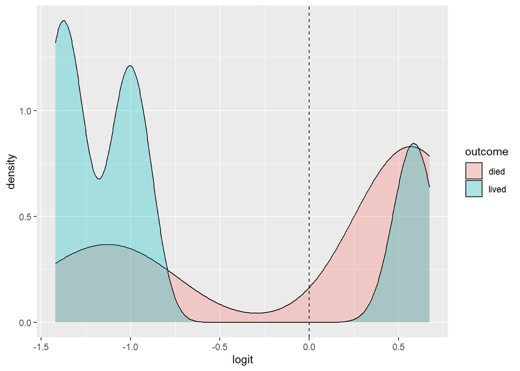

```r
log_horse$logit<-predict(fit3)
log_horse$outcome<-factor(log_horse$outcome,levels=c("died","lived"))

ggplot(log_horse,aes(logit, fill=outcome))+geom_density(alpha=.3)+
  geom_vline(xintercept=0,lty=2)
```